# HW1

Author

Brandy Recio

## Getting and describing data

QUESTION: is the daily concentration of PM2.5 (ug/m3) decreased in CA over the 20 years spanning from 2002 to 2022?

1. **Instructions:** For each of the two datasets, check the dimensions, headers, footers, variable names and variable types. Check the distribution of the key variable we are analyzing (PM). Write up a summary of all of your findings.Running Code

```r
library(readr)
my_2002_data <- read.csv("~/Downloads/2002.csv")
my_2022_data <- read.csv("~/Downloads/2022.csv")
```

```r
dim(my_2002_data)
```

```
[1] 15976    22
```

```r
head(my_2002_data)
```

```
        Date Source  Site.ID POC Daily.Mean.PM2.5.Concentration    Units
1 01/05/2002    AQS 60010007   1                           25.1 ug/m3 LC
2 01/06/2002    AQS 60010007   1                           31.6 ug/m3 LC
3 01/08/2002    AQS 60010007   1                           21.4 ug/m3 LC
4 01/11/2002    AQS 60010007   1                           25.9 ug/m3 LC
5 01/14/2002    AQS 60010007   1                           34.5 ug/m3 LC
6 01/17/2002    AQS 60010007   1                           41.0 ug/m3 LC
  Daily.AQI.Value Local.Site.Name Daily.Obs.Count Percent.Complete
1              81       Livermore               1              100
2              93       Livermore               1              100
3              74       Livermore               1              100
4              82       Livermore               1              100
5              98       Livermore               1              100
6             115       Livermore               1              100
  AQS.Parameter.Code AQS.Parameter.Description Method.Code
```

[output cut: 27 more lines]

```r
tail(my_2002_data)
```

```
            Date Source  Site.ID POC Daily.Mean.PM2.5.Concentration    Units
15971 12/10/2002    AQS 61131003   1                             15 ug/m3 LC
15972 12/13/2002    AQS 61131003   1                             15 ug/m3 LC
15973 12/22/2002    AQS 61131003   1                              1 ug/m3 LC
15974 12/25/2002    AQS 61131003   1                             23 ug/m3 LC
15975 12/28/2002    AQS 61131003   1                              5 ug/m3 LC
15976 12/31/2002    AQS 61131003   1                              6 ug/m3 LC
      Daily.AQI.Value      Local.Site.Name Daily.Obs.Count Percent.Complete
15971              62 Woodland-Gibson Road               1              100
15972              62 Woodland-Gibson Road               1              100
15973               6 Woodland-Gibson Road               1              100
15974              77 Woodland-Gibson Road               1              100
15975              28 Woodland-Gibson Road               1              100
15976              33 Woodland-Gibson Road               1              100
      AQS.Parameter.Code AQS.Parameter.Description Method.Code
```

[output cut: 27 more lines]

```r
dim(my_2022_data)
```

```
[1] 59918    22
```

```r
head(my_2022_data)
```

```
        Date Source  Site.ID POC Daily.Mean.PM2.5.Concentration    Units
1 01/01/2022    AQS 60010007   3                           12.7 ug/m3 LC
2 01/02/2022    AQS 60010007   3                           13.9 ug/m3 LC
3 01/03/2022    AQS 60010007   3                            7.1 ug/m3 LC
4 01/04/2022    AQS 60010007   3                            3.7 ug/m3 LC
5 01/05/2022    AQS 60010007   3                            4.2 ug/m3 LC
6 01/06/2022    AQS 60010007   3                            3.8 ug/m3 LC
  Daily.AQI.Value Local.Site.Name Daily.Obs.Count Percent.Complete
1              58       Livermore               1              100
2              60       Livermore               1              100
3              39       Livermore               1              100
4              21       Livermore               1              100
5              23       Livermore               1              100
6              21       Livermore               1              100
  AQS.Parameter.Code AQS.Parameter.Description Method.Code
```

[output cut: 27 more lines]

```r
tail(my_2022_data)
```

```
            Date Source  Site.ID POC Daily.Mean.PM2.5.Concentration    Units
59913 12/01/2022    AQS 61131003   1                            3.4 ug/m3 LC
59914 12/07/2022    AQS 61131003   1                            3.8 ug/m3 LC
59915 12/13/2022    AQS 61131003   1                            6.0 ug/m3 LC
59916 12/19/2022    AQS 61131003   1                           34.8 ug/m3 LC
59917 12/25/2022    AQS 61131003   1                           23.2 ug/m3 LC
59918 12/31/2022    AQS 61131003   1                            1.0 ug/m3 LC
      Daily.AQI.Value      Local.Site.Name Daily.Obs.Count Percent.Complete
59913              19 Woodland-Gibson Road               1              100
59914              21 Woodland-Gibson Road               1              100
59915              33 Woodland-Gibson Road               1              100
59916              99 Woodland-Gibson Road               1              100
59917              77 Woodland-Gibson Road               1              100
59918               6 Woodland-Gibson Road               1              100
      AQS.Parameter.Code AQS.Parameter.Description Method.Code
```

[output cut: 27 more lines]

```r
str(my_2002_data)
```

```
'data.frame':   15976 obs. of  22 variables:
 $ Date                          : chr  "01/05/2002" "01/06/2002" "01/08/2002" "01/11/2002" ...
 $ Source                        : chr  "AQS" "AQS" "AQS" "AQS" ...
 $ Site.ID                       : int  60010007 60010007 60010007 60010007 60010007 60010007 60010007 60010007 60010007 60010007 ...
 $ POC                           : int  1 1 1 1 1 1 1 1 1 1 ...
 $ Daily.Mean.PM2.5.Concentration: num  25.1 31.6 21.4 25.9 34.5 41 29.3 15 18.8 37.9 ...
 $ Units                         : chr  "ug/m3 LC" "ug/m3 LC" "ug/m3 LC" "ug/m3 LC" ...
 $ Daily.AQI.Value               : int  81 93 74 82 98 115 89 62 69 107 ...
 $ Local.Site.Name               : chr  "Livermore" "Livermore" "Livermore" "Livermore" ...
 $ Daily.Obs.Count               : int  1 1 1 1 1 1 1 1 1 1 ...
 $ Percent.Complete              : num  100 100 100 100 100 100 100 100 100 100 ...
 $ AQS.Parameter.Code            : int  88101 88101 88101 88101 88101 88101 88101 88101 88101 88101 ...
 $ AQS.Parameter.Description     : chr  "PM2.5 - Local Conditions" "PM2.5 - Local Conditions" "PM2.5 - Local Conditions" "PM2.5 - Local Conditions" ...
 $ Method.Code                   : int  120 120 120 120 120 120 120 120 120 120 ...
 $ Method.Description            : chr  "Andersen RAAS2.5-300 PM2.5 SEQ w/WINS" "Andersen RAAS2.5-300 PM2.5 SEQ w/WINS" "Andersen RAAS2.5-300 PM2.5 SEQ w/WINS" "Andersen RAAS2.5-300 PM2.5 SEQ w/WINS" ...
 $ CBSA.Code                     : int  41860 41860 41860 41860 41860 41860 41860 41860 41860 41860 ...
 $ CBSA.Name                     : chr  "San Francisco-Oakland-Hayward, CA" "San Francisco-Oakland-Hayward, CA" "San Francisco-Oakland-Hayward, CA" "San Francisco-Oakland-Hayward, CA" ...
 $ State.FIPS.Code               : int  6 6 6 6 6 6 6 6 6 6 ...
 $ State                         : chr  "California" "California" "California" "California" ...
 $ County.FIPS.Code              : int  1 1 1 1 1 1 1 1 1 1 ...
 $ County                        : chr  "Alameda" "Alameda" "Alameda" "Alameda" ...
 $ Site.Latitude                 : num  37.7 37.7 37.7 37.7 37.7 ...
 $ Site.Longitude                : num  -122 -122 -122 -122 -122 ...
```

```r
str(my_2022_data)
```

```
'data.frame':   59918 obs. of  22 variables:
 $ Date                          : chr  "01/01/2022" "01/02/2022" "01/03/2022" "01/04/2022" ...
 $ Source                        : chr  "AQS" "AQS" "AQS" "AQS" ...
 $ Site.ID                       : int  60010007 60010007 60010007 60010007 60010007 60010007 60010007 60010007 60010007 60010007 ...
 $ POC                           : int  3 3 3 3 3 3 3 3 3 3 ...
 $ Daily.Mean.PM2.5.Concentration: num  12.7 13.9 7.1 3.7 4.2 3.8 2.3 6.9 13.6 11.2 ...
 $ Units                         : chr  "ug/m3 LC" "ug/m3 LC" "ug/m3 LC" "ug/m3 LC" ...
 $ Daily.AQI.Value               : int  58 60 39 21 23 21 13 38 59 55 ...
 $ Local.Site.Name               : chr  "Livermore" "Livermore" "Livermore" "Livermore" ...
 $ Daily.Obs.Count               : int  1 1 1 1 1 1 1 1 1 1 ...
 $ Percent.Complete              : num  100 100 100 100 100 100 100 100 100 100 ...
 $ AQS.Parameter.Code            : int  88101 88101 88101 88101 88101 88101 88101 88101 88101 88101 ...
 $ AQS.Parameter.Description     : chr  "PM2.5 - Local Conditions" "PM2.5 - Local Conditions" "PM2.5 - Local Conditions" "PM2.5 - Local Conditions" ...
 $ Method.Code                   : int  170 170 170 170 170 170 170 170 170 170 ...
 $ Method.Description            : chr  "Met One BAM-1020 Mass Monitor w/VSCC" "Met One BAM-1020 Mass Monitor w/VSCC" "Met One BAM-1020 Mass Monitor w/VSCC" "Met One BAM-1020 Mass Monitor w/VSCC" ...
 $ CBSA.Code                     : int  41860 41860 41860 41860 41860 41860 41860 41860 41860 41860 ...
 $ CBSA.Name                     : chr  "San Francisco-Oakland-Hayward, CA" "San Francisco-Oakland-Hayward, CA" "San Francisco-Oakland-Hayward, CA" "San Francisco-Oakland-Hayward, CA" ...
 $ State.FIPS.Code               : int  6 6 6 6 6 6 6 6 6 6 ...
 $ State                         : chr  "California" "California" "California" "California" ...
 $ County.FIPS.Code              : int  1 1 1 1 1 1 1 1 1 1 ...
 $ County                        : chr  "Alameda" "Alameda" "Alameda" "Alameda" ...
 $ Site.Latitude                 : num  37.7 37.7 37.7 37.7 37.7 ...
 $ Site.Longitude                : num  -122 -122 -122 -122 -122 ...
```

```r
summary(my_2002_data$Daily.Mean.PM2.5.Concentration)
```

```
   Min. 1st Qu.  Median    Mean 3rd Qu.    Max.
   0.00    7.00   12.00   16.12   20.50  104.30
```

```r
summary(my_2022_data$Daily.Mean.PM2.5.Concentration)
```

```
   Min. 1st Qu.  Median    Mean 3rd Qu.    Max.
 -6.700   4.100   6.800   8.414  10.700 302.500
```

```r
my_2022_data <- my_2022_data[with(my_2022_data, Daily.Mean.PM2.5.Concentration >= 0), ]
my_2022_data <- my_2022_data[order(my_2022_data$Daily.Mean.PM2.5.Concentration), ]
head(my_2022_data)
```

```
           Date Source  Site.ID POC Daily.Mean.PM2.5.Concentration    Units
896  07/07/2022    AQS 60010011   3                              0 ug/m3 LC
919  07/31/2022    AQS 60010011   3                              0 ug/m3 LC
1934 05/29/2022    AQS 60070008   3                              0 ug/m3 LC
2211 01/08/2022    AQS 60072002   3                              0 ug/m3 LC
2236 02/02/2022    AQS 60072002   3                              0 ug/m3 LC
2244 02/10/2022    AQS 60072002   3                              0 ug/m3 LC
     Daily.AQI.Value    Local.Site.Name Daily.Obs.Count Percent.Complete
896                0       Oakland West               1              100
919                0       Oakland West               1              100
1934               0  Chico-East Avenue               1              100
2211               0 Paradise - Theater               1              100
2236               0 Paradise - Theater               1              100
2244               0 Paradise - Theater               1              100
     AQS.Parameter.Code              AQS.Parameter.Description Method.Code
```

[output cut: 27 more lines]

**Description:** while the mean PM2.5 concentration from 2002 was 16.12 ug/m3, data from 2022 had a lower mean value of 8.41 ug/m3 but had more extreme values including negative numbers. And looking at the distribution of the key variable (PM2.5) at 2002 and 2022, I noticed their data is right skewed.

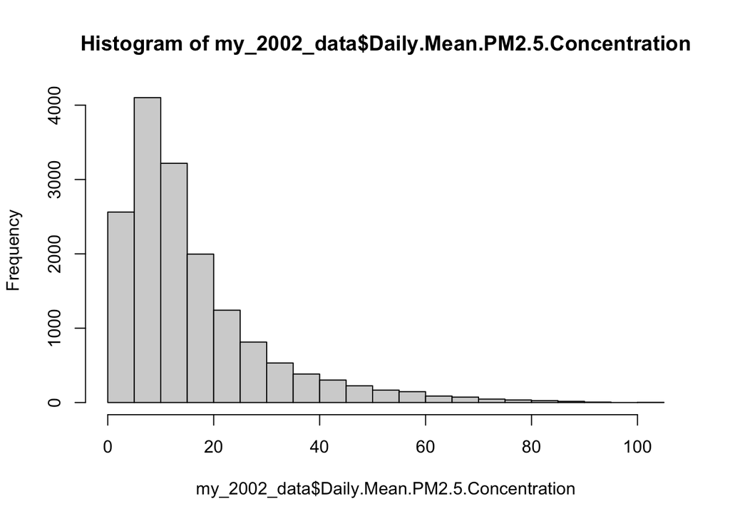

```r
hist(my_2002_data$Daily.Mean.PM2.5.Concentration)
```

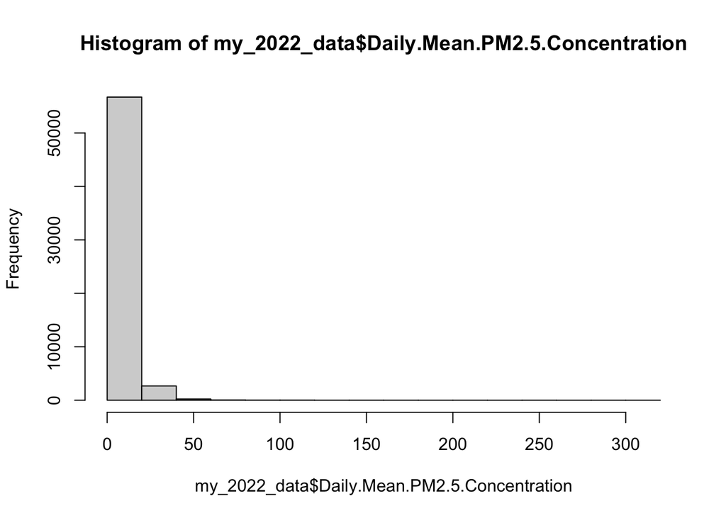

```r
hist(my_2022_data$Daily.Mean.PM2.5.Concentration)
```

2. Combine the two years of data into one data frame. Use the `Date` variable to create a new column for year, which will serve as an identifier. Change the names of the key variables so that they are easier to refer to in your code.

   ```r
   # Add a year column from the Date variable
   my_2002_data$Year <- format(as.Date(my_2002_data$Date, format = "%m/%d/%Y"), "%Y")
   my_2022_data$Year <- format(as.Date(my_2022_data$Date, format = "%m/%d/%Y"), "%Y")

   # Combine into one data frame
   combined_data <- rbind(my_2002_data, my_2022_data)

   # Rename key variables
   names(combined_data)[names(combined_data) == "Daily.Mean.PM2.5.Concentration"] <- "PM"
   names(combined_data)[names(combined_data) == "Daily.AQI.Value"] <- "AQI"
   names(combined_data)[names(combined_data) == "Local.Site.Name"] <- "Sites"
   names(combined_data)[names(combined_data) == "Site.Latitude"] <- "Latitude"
   names(combined_data)[names(combined_data) == "Site.Longitude"] <- "Longitude"
   # Check result
   head(combined_data)
   ```

   ```
           Date Source  Site.ID POC   PM    Units AQI     Sites Daily.Obs.Count
   1 01/05/2002    AQS 60010007   1 25.1 ug/m3 LC  81 Livermore               1
   2 01/06/2002    AQS 60010007   1 31.6 ug/m3 LC  93 Livermore               1
   3 01/08/2002    AQS 60010007   1 21.4 ug/m3 LC  74 Livermore               1
   4 01/11/2002    AQS 60010007   1 25.9 ug/m3 LC  82 Livermore               1
   5 01/14/2002    AQS 60010007   1 34.5 ug/m3 LC  98 Livermore               1
   6 01/17/2002    AQS 60010007   1 41.0 ug/m3 LC 115 Livermore               1
     Percent.Complete AQS.Parameter.Code AQS.Parameter.Description Method.Code
   1              100              88101  PM2.5 - Local Conditions         120
   2              100              88101  PM2.5 - Local Conditions         120
   3              100              88101  PM2.5 - Local Conditions         120
   4              100              88101  PM2.5 - Local Conditions         120
   5              100              88101  PM2.5 - Local Conditions         120
   6              100              88101  PM2.5 - Local Conditions         120
                        Method.Description CBSA.Code
   ```

   [output cut: 20 more lines]

3. Create a basic map (or maps) in either `leaflet` or `ggplot` showing the locations of the monitoring sites, using different colors for each year. Summarize the spatial distribution of the sites. Does this distribution change from 2002 to 2022?

   ```r
   library(dplyr)
   library(leaflet)

   # Deduplicate by Year + Sites
   sites <- combined_data %>%
     filter(!is.na(Latitude), !is.na(Longitude)) %>%
     distinct(Year, Sites, .keep_all = TRUE)

   # Color palette by year
   pal <- colorFactor(palette = "Set1", domain = combined_data$Year)

   leaflet(sites) %>%
     addTiles() %>%
     addCircleMarkers(
       lng = ~Longitude,
       lat = ~Latitude,
       color = ~pal(Year),
       stroke = FALSE,
       fillOpacity = 1,
       radius = 6,
       popup = ~paste0(
         "<b>Site: </b>", Sites, "<br/>",
         "<b>Year: </b>", Year, "<br/>",
         "<b>Lat/Lon: </b>", round(Latitude, 4), ", ", round(Longitude, 4)
       )
     ) %>%
     addLegend("bottomright", pal = pal, values = ~Year, title = "Year")
   ```

[interactive chart not shown]

**Description:** the distribution clearly changed from 2002 to 2022. There were considerable more monitoring sites in 2022 than 2002 in the state of California which is expected given the higher number of observation during 2022 compared to 2002.

4. Check for any data issues such as missing or implausible values of PM in the combined dataset. Calculate the proportion of missing/implausible values for each year and report any temporal patterns you see in these observations.

```r
# Define implausible as missing, negative, or unreasonably high (e.g., > 400 µg/m³)
quality_check <- combined_data %>%
  mutate(
    invalid_PM = ifelse(is.na(PM) | PM < 0 | PM > 400, 1, 0)
  ) %>%
  group_by(Year) %>%
  summarise(
    total_obs = n(),
    invalid_obs = sum(invalid_PM),
    prop_invalid = mean(invalid_PM)
  )

print(quality_check)
```

```
# A tibble: 2 × 4
  Year  total_obs invalid_obs prop_invalid
  <chr>     <int>       <dbl>        <dbl>
1 2002      15976           0            0
2 2022      59703           0            0
```

**Description:** previously I removed negative values found in 2022, the following code ensures there is no implausible values > 400 µg/m³ and missing values that could disrupt the good interpretation of the data.

- there is definitely temporal changes between both years, PM2.5 concentration decreased in average from 2002 to 2022. However, 2022 data contains more extreme values not found in 2002 data.
5. Explore the main question of interest at three different levels of spatial resolution. Create data visualizations (e.g. boxplots, histograms, line plots, violin plots) **and** summary statistics that best suit each level of the analysis. Be sure to write up explanations of what you observe at each level.

   **Level 1: State. Examine the primary question for the entire state.**

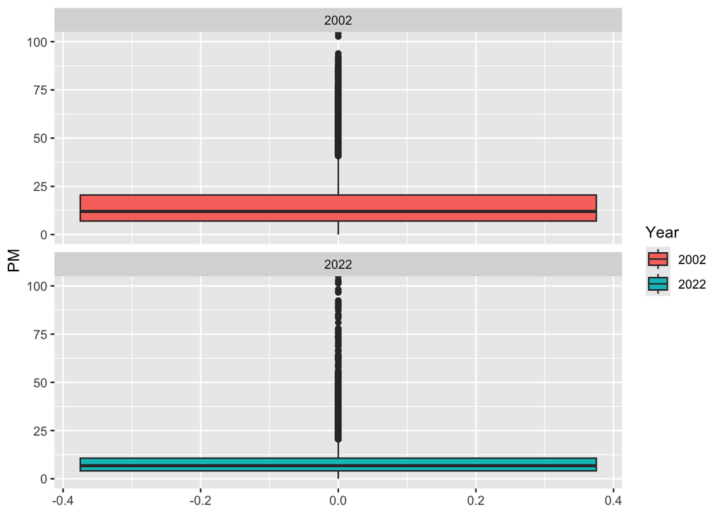

   ```r
   library(ggplot2)
   library(dplyr)

   ##PLOT 1
   combined_data %>%
     filter(!is.na(PM)) %>%
     ggplot(aes(y = PM, fill = Year)) +
     geom_boxplot() +
     facet_wrap(~Year, nrow = 2) +
     coord_cartesian(ylim = c(0, 100))   # restrict y-axis to 0–100
   ```

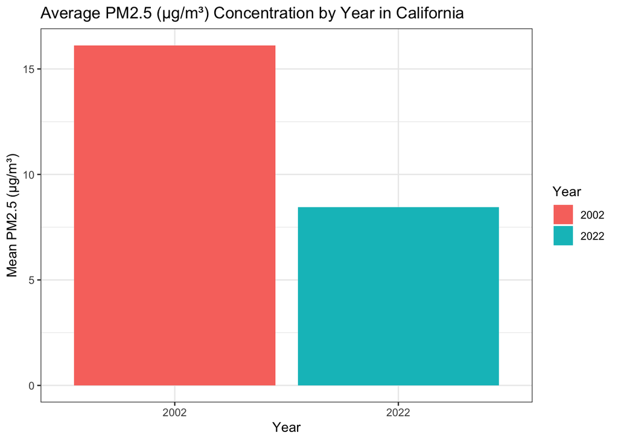

   ```r
   ##PLOT 2
   combined_data %>%
     filter(!is.na(PM)) %>%
     group_by(Year) %>%
     summarise(mean_PM = mean(PM, na.rm = TRUE)) %>%
     ggplot(aes(x = Year, y = mean_PM, fill = Year)) +
     geom_bar(stat = "identity", position = "dodge") +
     labs(
       title = "Average PM2.5 (µg/m³) Concentration by Year in California",
       x = "Year",
       y = "Mean PM2.5 (µg/m³)"
     ) +
     theme_bw()
   ```

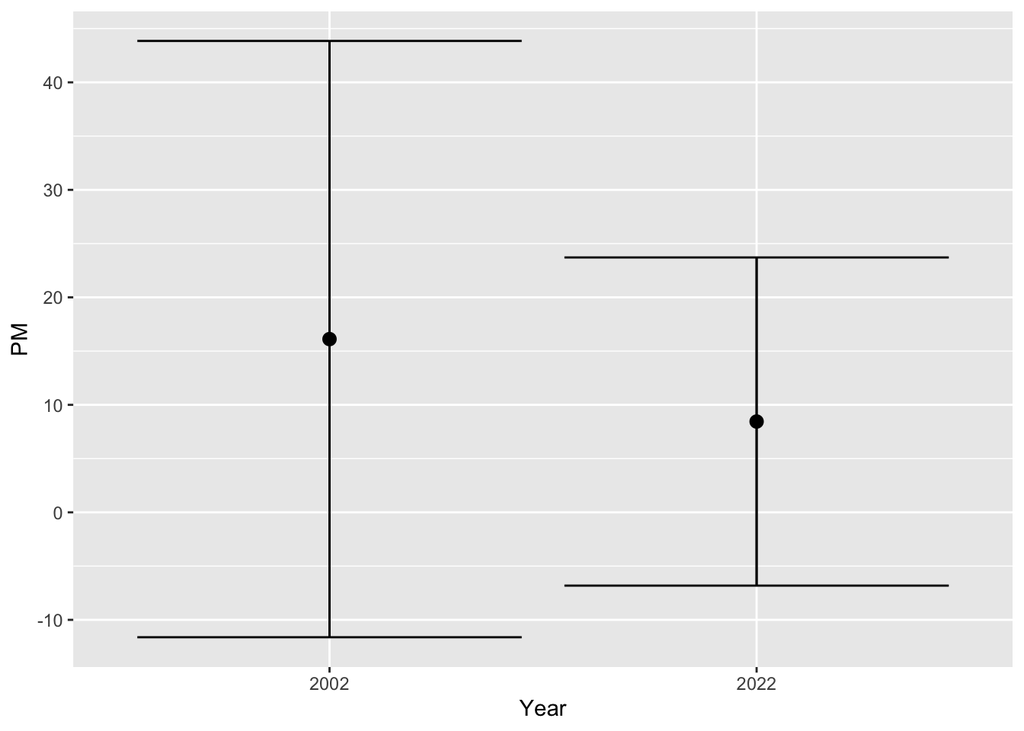

   ```r
   ##PLOT 3
   combined_data %>%
     filter(!is.na(PM)) %>%
     ggplot(mapping=aes(x=Year, y=PM)) +
     stat_summary(fun.data = "mean_sdl", geom="errorbar") +
     stat_summary(fun.data = "mean_sdl")
   ```

   ```r
   ##Summary Statistics
   PM <- combined_data %>%
     group_by(Year) %>%
     summarise(PM = max(PM, na.rm = TRUE)) %>%
     ungroup()
   PM
   ```

   ```
   # A tibble: 2 × 2
     Year     PM
     <chr> <dbl>
   1 2002   104.
   2 2022   302.
   ```

   **Level 2: County. Examine the primary question for every county in California.**

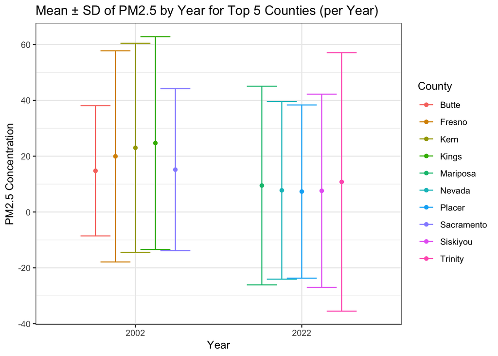

```r
library(dplyr)
library(ggplot2)
library(ggridges)
library(tidytext)

##PLOT 1
# Find top 5 counties by max PM per year
top5_counties <- combined_data %>%
  group_by(Year, County) %>%
  summarise(max_PM = max(PM, na.rm = TRUE), .groups = "drop") %>%
  group_by(Year) %>%
  slice_max(max_PM, n = 5, with_ties = FALSE) %>%
  ungroup()

# Filter dataset to those counties and plot
combined_data %>%
  inner_join(top5_counties %>% select(Year, County), by = c("Year", "County")) %>%
  filter(!is.na(PM)) %>%
  ggplot(aes(x = Year, y = PM, color = County, group = County)) +
  stat_summary(fun.data = "mean_sdl", geom = "errorbar",
               position = position_dodge(width = 0.6)) +
  stat_summary(fun = mean, geom = "point",
               position = position_dodge(width = 0.6)) +
  labs(
    title = "Mean ± SD of PM2.5 by Year for Top 5 Counties (per Year)",
    y = "PM2.5 Concentration",
    x = "Year",
    color = "County"
  ) +
  theme_bw()
```

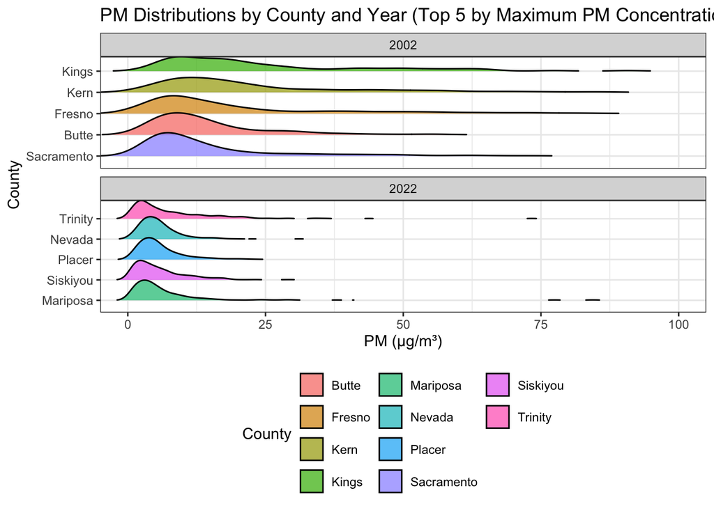

```r
##PLOT 2
topN <- 5  # show top 5 counties (by number of observations) per year

# Find top 5 counties per year by max PM
top_counties <- combined_data %>%
  filter(!is.na(PM)) %>%
  group_by(Year, County) %>%
  summarise(max_PM = max(PM, na.rm = TRUE), .groups = "drop") %>%
  group_by(Year) %>%
  slice_max(max_PM, n = topN, with_ties = FALSE)

# Keep only those top counties
plot_data <- combined_data %>%
  inner_join(top_counties %>% select(Year, County), by = c("Year","County")) %>%
  filter(!is.na(PM), PM >= 0, PM <= 100) %>%
  mutate(County_ord = reorder_within(County, PM, Year, fun = median))

# Plot
ggplot(plot_data, aes(x = PM, y = County_ord, fill = County)) +
  geom_density_ridges(alpha = 0.7, scale = 1.1, rel_min_height = 0.01) +
  scale_y_reordered() +
  facet_wrap(~Year, nrow = 2, scales = "free_y") +
  coord_cartesian(xlim = c(0, 100)) +
  labs(
    title = "PM Distributions by County and Year (Top 5 by Maximum PM Concentration)",
    x = "PM (µg/m³)",
    y = "County",
    fill = "County"
  ) +
  theme_bw() +
  theme(legend.position = "bottom") +
  guides(fill = guide_legend(ncol = 3))
```

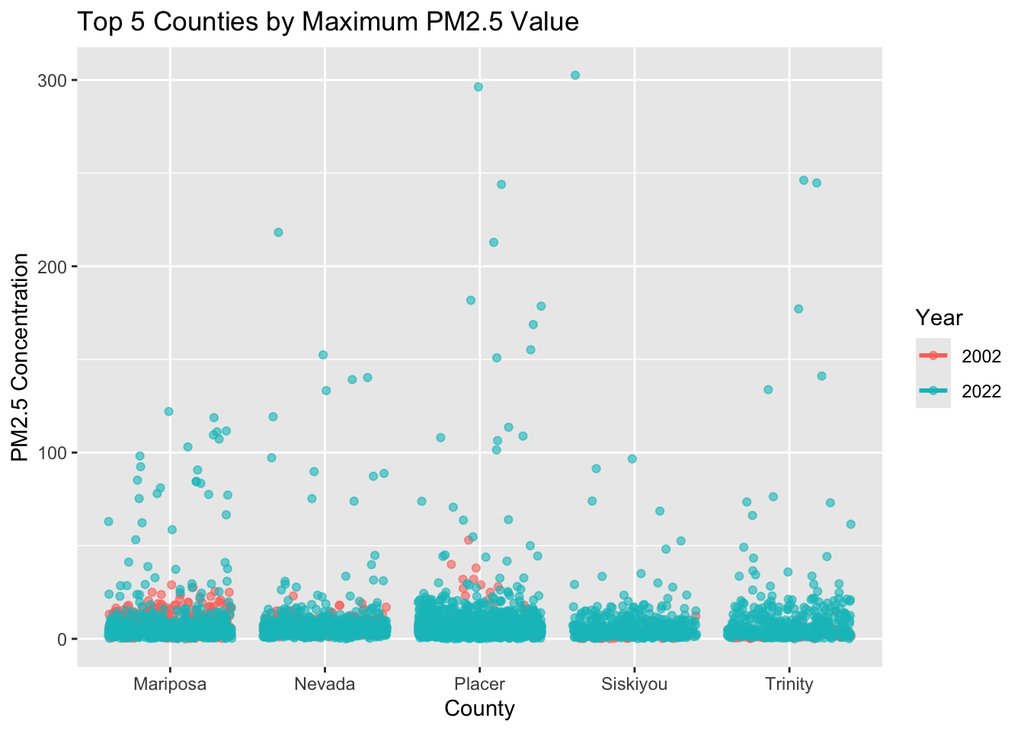

```r
##PLOT 3
# Top 5 counties by maximum PM value
top5_counties <- combined_data %>%
  group_by(County) %>%
  summarise(max_PM = max(PM, na.rm = TRUE)) %>%
  arrange(desc(max_PM)) %>%
  slice_head(n = 5) %>%
  pull(County)

# Filter to those counties and plot
combined_data %>%
  filter(!is.na(PM), County %in% top5_counties) %>%
  ggplot(aes(x = County, y = PM, color = Year)) +
  geom_jitter(alpha = 0.6) +
  stat_smooth(method = "lm", se = FALSE) +
  labs(title = "Top 5 Counties by Maximum PM2.5 Value",
       y = "PM2.5 Concentration",
       x = "County")
```

```r
##Summary Statistics
PM <- combined_data %>%
  group_by(Year, County) %>%
  summarise(max_PM = max(PM, na.rm = TRUE), .groups = "drop") %>%
  group_by(Year) %>%
  slice_max(max_PM, n = 5, with_ties = FALSE) %>%
  ungroup()

PM
```

```
# A tibble: 10 × 3
   Year  County     max_PM
   <chr> <chr>       <dbl>
 1 2002  Kern        104.
 2 2002  Fresno       92.5
 3 2002  Sacramento   91
 4 2002  Kings        90.7
 5 2002  Butte        88
 6 2022  Siskiyou    302.
 7 2022  Placer      296.
 8 2022  Trinity     246.
 9 2022  Nevada      218.
10 2022  Mariposa    122
```

**Level 3: City. Restrict the data to sites in Los Angeles county and examine the primary question for every site.**

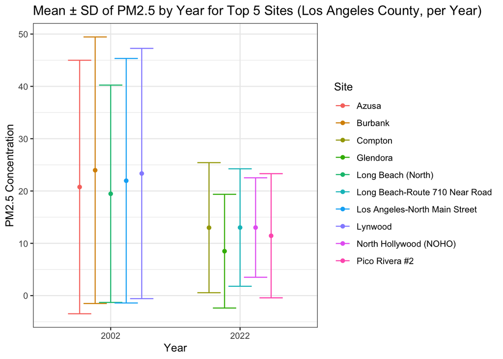

```r
library(dplyr)
library(ggplot2)

##PLOT1
# Find top 5 sites *per year* in LA County by maximum PM
top5_sites_LA <- combined_data %>%
  filter(County == "Los Angeles") %>%
  group_by(Year, Sites) %>%
  summarise(max_PM = max(PM, na.rm = TRUE), .groups = "drop") %>%
  group_by(Year) %>%
  slice_max(max_PM, n = 5, with_ties = FALSE) %>%
  ungroup()

# Plot mean ± SD for those top 5 sites per year
combined_data %>%
  inner_join(top5_sites_LA %>% select(Year, Sites), by = c("Year", "Sites")) %>%
  filter(!is.na(PM), County == "Los Angeles") %>%
  ggplot(aes(x = Year, y = PM, color = Sites, group = Sites)) +
  stat_summary(fun.data = "mean_sdl", geom = "errorbar", position = position_dodge(width = 0.6)) +
  stat_summary(fun = mean, geom = "point", position = position_dodge(width = 0.6)) +
  labs(
    title = "Mean ± SD of PM2.5 by Year for Top 5 Sites (Los Angeles County, per Year)",
    y = "PM2.5 Concentration",
    x = "Year",
    color = "Site"
  ) +
  theme_bw()
```

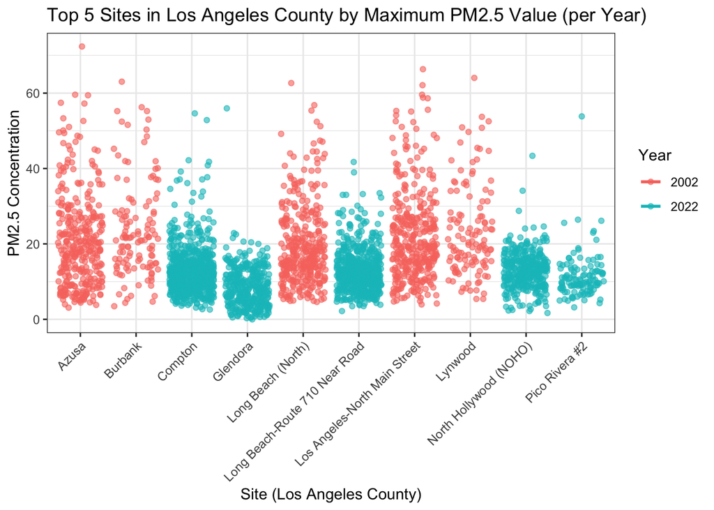

```r
##PLOT2
# Top 5 Sites by maximum PM per Year (restricted to Los Angeles County)
top5_sites_LA <- combined_data %>%
  filter(County == "Los Angeles") %>%                    # keep only LA County
  group_by(Year, Sites) %>%
  summarise(max_PM = max(PM, na.rm = TRUE), .groups = "drop") %>%
  group_by(Year) %>%
  slice_max(max_PM, n = 5, with_ties = FALSE) %>%
  ungroup()

# Filter to those LA sites and plot
combined_data %>%
  inner_join(top5_sites_LA %>% select(Year, Sites), by = c("Year", "Sites")) %>%
  filter(!is.na(PM), County == "Los Angeles") %>%
  ggplot(aes(x = Sites, y = PM, color = Year)) +
  geom_jitter(alpha = 0.6) +
  stat_smooth(method = "lm", se = FALSE) +
  labs(title = "Top 5 Sites in Los Angeles County by Maximum PM2.5 Value (per Year)",
       y = "PM2.5 Concentration",
       x = "Site (Los Angeles County)") +
  theme_bw() +
  theme(axis.text.x = element_text(angle = 45, hjust = 1))
```

```r
##Summary Statistics
PM_LA_sites <- combined_data %>%
  filter(County == "Los Angeles") %>%              # restrict to Los Angeles County
  group_by(Year, Sites) %>%                        # group by Year and Site
  summarise(max_PM = max(PM, na.rm = TRUE), .groups = "drop") %>%
  group_by(Year) %>%                               # within each year
  slice_max(max_PM, n = 5, with_ties = FALSE) %>%  # top 5 sites per year
  arrange(Year, desc(max_PM)) %>%
  ungroup()

PM_LA_sites
```

```
# A tibble: 10 × 3
   Year  Sites                          max_PM
   <chr> <chr>                           <dbl>
 1 2002  Azusa                            72.4
 2 2002  Los Angeles-North Main Street    66.3
 3 2002  Lynwood                          64
 4 2002  Burbank                          63
 5 2002  Long Beach (North)               62.7
 6 2022  Glendora                         56
 7 2022  Compton                          54.6
 8 2022  Pico Rivera #2                   53.8
 9 2022  North Hollywood (NOHO)           43.4
10 2022  Long Beach-Route 710 Near Road   41.7
```

**Conclusions**

- At the state level: even though 2002 had higher mean PM2.5 concentration than 2022 (16.12 vs 8.4), 2022 data reported the highest concentration of 302.5 compared to 104.3 of 2002.
- At the county level: I showed the top 5 counties with most PM concentration, and I found that while Kern reached the highest concentration in 2002 with 104.3, Siskiyou did so in 2022 with 302.5.
- At the city level: within Los Angeles, Azusa had the highest PM2.5 concentration in 2002 while Glendora had the highest in 2022.

  Thus, we can conclude that the mean daily concentration of PM2.5 decreased in CA over the 20 years spanning from 2002 to 2022, but 2022 reported higher maximum concentrations compared to 2002 depending on specific locations.